# NEON Data Analysis of Verrucomicrobiota and Niwot Ridge

Evo-Geno Final Project Spring 2024

Michelle Le, Olivia Mooradian, Jason Chen, Sofia Blomqvist

# Abstract

Verrucomicrobiota are present in almost all soil, but it was originally thought to be at low frequencies since there were only a few studies that focused on the Verrucomicrobiota quantities. However, with ecological data from The National Ecological Observatory Network (NEON), funded by the National Science Foundation, more data has surfaced, providing information about the bacteria across ecosystems, with our data focusing on Niwot Ridge, Colorado. With the increasing temperatures due to global warming, it is important to take notice of the different bacteria that are growing and changing along with the climate. Where they require very specific environments to grow, taking notice of the different features of existing environments is massively important. In the near future where climates might not be able to keep the bacteria alive, it would be vital to provide a possible man made environment that can facilitate the bacteria growth with the data collected, allowing for a deeper understanding of the bacteria.

# Motivating Reasons

Bacteria play many important roles in the soil of ecosystem such as providing soil structure, soil aggregation, recycling of soil nutrients, and water recycling. They also serve an important function in breaking down organic residues, carbon compounds and simple sugars, as well as taking up nutrients into their cell membranes such as nitrogen (“Role of Soil Bacteria” n.d.). These functions are important for plant growth and maintaining a healthy ecosystem, i.e. continuous recycling of nutrients, maintaining a balance of pathogenic and non-pathogenic bacterial species, and soil stability. The phylum of bacteria Verrucromicrobiota are widespread and while the research surrounding their functions is limited it is thought that they play a major role in carbon degeneration and have a greater ability to survive in a variety of conditions than previously thought. Just like other bacteria, Verrucromicrobiota must be able to adapt to the diverse microenvironments of the soil in order to provide these ecological benefits, and with increasing global temperatures that generally raise microbial activity and in turn decrease the amount of organic matter in soil (Ruan et al. 2023) it will be important to monitor their abundance in different ecosystems across time.

# Introduction

The National Ecological Observatory Network (NEON) funded by the National Science Foundation is a large, continental-scale project with the purpose of collecting long-term open access ecological data at various sites throughout the United States including Hawaii and Puerto Rico. This data enables researchers to conduct studies addressing questions related to important environmental challenges. The NEON database includes information on freshwater ecosystems such as rivers and streams as well as terrestrial ecosystems ranging from mountainous tundra to tropical rainforests. We are particularly interested in the microbe metagenome sequence data that NEON has collected which includes metagenome-assembled genomes (MAGs) of various phyla and orders of bacteria at different sites across the United States (“Niwot Ridge NEON NSF NEON Open Data to Understand Our Ecosystems” n.d.). For our specific project, we focus on the NEON project site located in the Niwot Ridge in Boulder, Colorado (NIWO), and the bacteria Verrucomicrobiota. In our study, we are using NEON data from the NIWO site to explore the relationship between Verrucomicrobiota abundance and soil conditions, and we explore how this relationship impacts Verrucomicrobiota growth and what this could mean for the ecosystems the bacteria inhabits.

Verrucomicrobiota is a free living, widespread phylum of bacteria surviving in freshwater, marine, terrestrial soil, and animal gut, and are significant contributors to carbon cycling. Despite their prevalence, they are underrepresented in databases, limiting our understanding of their ecological roles (Bergmann et al. 2011). Recent findings highlight Verrucomicrobiota’s role as specialist organic polymer degraders capable of adapting to diverse environmental conditions, expanding our understanding of their ecological significance (Nixon et al. 2019).

# Methods

### Loading Libraries and Data

```r
library(tidyverse)
library(knitr)
library(tidyverse)
library(knitr)
library(ggtree)
library(TDbook)
library(ggimage)
library(rphylopic)
library(treeio)
library(tidytree)
library(ape)
library(TreeTools)
library(phytools)
library(ggnewscale)
library(ggtreeExtra)
library(ggstar)
library(zoo)
library(usethis)
```

```r
NEON_MAGs <- read_csv("data/NEON/GOLD_Study_ID_Gs0161344_NEON_2024_4_21.csv") %>%
  select(-c(`GOLD Study ID`, `Bin Methods`, `Created By`, `Date Added`, `Bin Lineage`)) %>%
  mutate("Assembly Type" = case_when(`Genome Name` == "NEON combined assembly" ~ `Genome Name`,
                            TRUE ~ "Individual")) %>%
  mutate_at("Assembly Type", str_replace, "NEON combined assembly", "Combined") %>%
  mutate_at("GTDB-Tk Taxonomy Lineage", str_replace, "d__", "") %>%
  mutate_at("GTDB-Tk Taxonomy Lineage", str_replace, "p__", "") %>%
  mutate_at("GTDB-Tk Taxonomy Lineage", str_replace, "c__", "") %>%
  mutate_at("GTDB-Tk Taxonomy Lineage", str_replace, "o__", "") %>%
  mutate_at("GTDB-Tk Taxonomy Lineage", str_replace, "f__", "") %>%
  mutate_at("GTDB-Tk Taxonomy Lineage", str_replace, "g__", "") %>%
  mutate_at("GTDB-Tk Taxonomy Lineage", str_replace, "s__", "") %>%
  separate(`GTDB-Tk Taxonomy Lineage`, c("Domain", "Phylum", "Class", "Order", "Family", "Genus", "Species"), ";", remove = FALSE) %>%
  mutate_at("Domain", na_if,"") %>%
  mutate_at("Phylum", na_if,"") %>%
  mutate_at("Class", na_if,"") %>%
  mutate_at("Order", na_if,"") %>%
  mutate_at("Family", na_if,"") %>%
  mutate_at("Genus", na_if,"") %>%
  mutate_at("Species", na_if,"") %>%

  mutate_at("Genome Name", str_replace, "Terrestrial soil microbial communities from ", "") %>%
  separate(`Genome Name`, c("Site","Sample Name"), " - ") %>%
  mutate_at("Sample Name", str_replace, "-comp-1", "") %>%
  separate(`Sample Name`, c("Site ID","subplot.layer.date"), "_", remove = FALSE,) %>%
  separate(`subplot.layer.date`, c("Subplot", "Layer", "Date"), "-")
```

```r
NEON_metagenomes <- read_tsv("data/NEON/exported_img_data_Gs0161344_NEON.tsv") %>%
  select(-c(`Domain`, `Sequencing Status`, `Sequencing Center`)) %>%
  rename(`Genome Name` = `Genome Name / Sample Name`) %>%
  filter(str_detect(`Genome Name`, 're-annotation', negate = T)) %>%
  filter(str_detect(`Genome Name`, 'WREF plot', negate = T))
```

```r
NEON_metagenomes <- NEON_metagenomes %>%
  mutate_at("Genome Name", str_replace, "Terrestrial soil microbial communities from ", "") %>%
  separate(`Genome Name`, c("Site","Sample Name"), " - ") %>%
  mutate_at("Sample Name", str_replace, "-comp-1", "") %>%
  separate(`Sample Name`, c("Site ID","subplot.layer.date"), "_", remove = FALSE,) %>%
  separate(`subplot.layer.date`, c("Subplot", "Layer", "Date"), "-")
```

```r
NEON_chemistry <- read_tsv("data/NEON/neon_plot_soilChem1_metadata.tsv") %>%
  mutate_at("genomicsSampleID", str_replace, "-COMP", "")
```

### Creating Data Frames/Preparing Data

#### NEON

```r
NEON_data <- NEON_MAGs %>%
  left_join(NEON_metagenomes, by = "Sample Name") %>%
  left_join(NEON_chemistry, by = c("Sample Name" = "genomicsSampleID")) %>%
  rename("label" = "Bin ID")

NEON_data_Verruco <- NEON_data %>%
 filter(str_detect(Phylum, "Verrucomicrobiota"))

NEON_data_NIWO <- NEON_data %>%
  filter(str_detect(Site.x, "Niwot Ridge"))
```

#### Trees

```r
tree_arc <- read.tree("data/NEON/gtdbtk.ar53.decorated.tree")
tree_bac <- read.tree("data/NEON/gtdbtk.bac120.decorated.tree")
```

```r
node_vector_bac = c(tree_bac$tip.label,tree_bac$node.label)

grep("Verrucomicrobiota", node_vector_bac, value = TRUE)
```

```
## [1] "'1.0:p__Verrucomicrobiota; c__Verrucomicrobiae'"
```

```r
match(grep("Verrucomicrobiota", node_vector_bac, value = TRUE), node_vector_bac)
```

```
## [1] 2563
```

```r
tree_bac_preorder <- Preorder(tree_bac)
tree_Verruco <- Subtree(tree_bac_preorder, 2563)
```

# Results

## Environmental Data

### Soil Data - Verrucomicrobiota vs. all MAGs

#### Verrucomicrobiota Soil Temperature Distribution

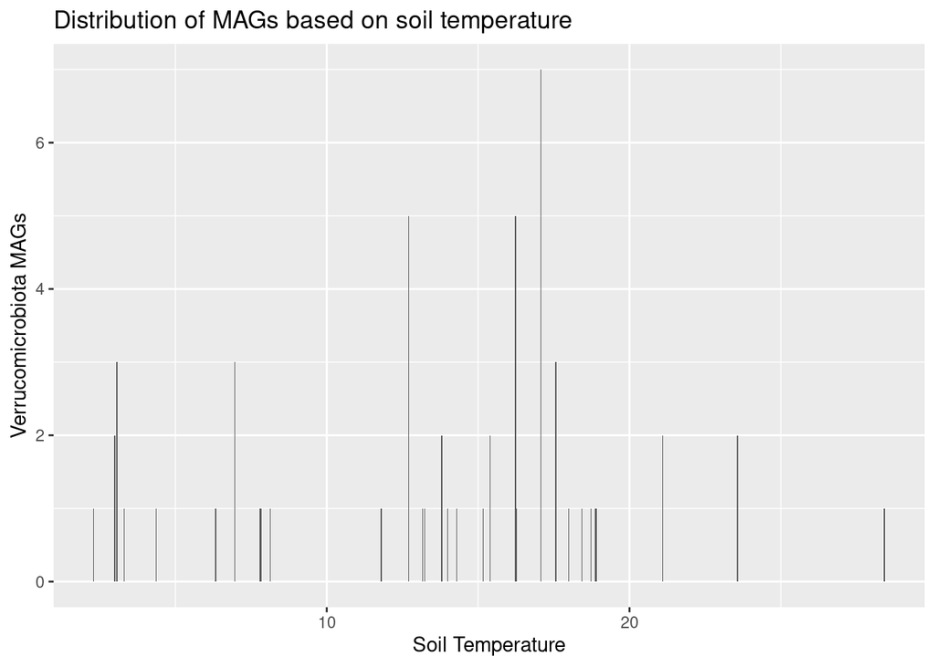

```r
NEON_data_Verruco %>%
  ggplot(aes(x = soilTemp)) +
  geom_bar()+
  labs(title = "Distribution of MAGs based on soil temperature", y = "Verrucomicrobiota MAGs", x= "Soil Temperature")
```

#### Verrucomicrobiota Soil pH Distribution

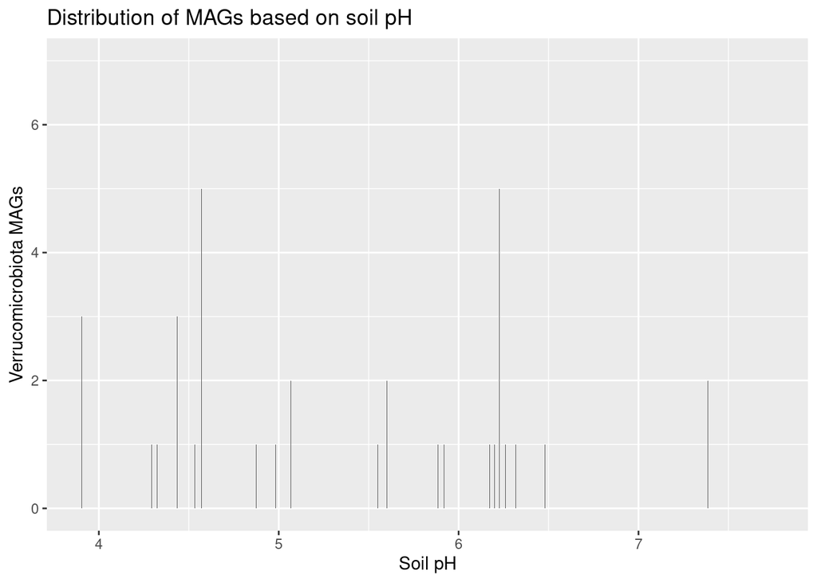

```r
NEON_data_Verruco %>%
  ggplot(aes(x = soilInWaterpH)) +
  geom_bar()+
  labs(title = "Distribution of MAGs based on soil pH", y = "Verrucomicrobiota MAGs", x= "Soil pH")
```

#### Total MAGs Soil Temperature

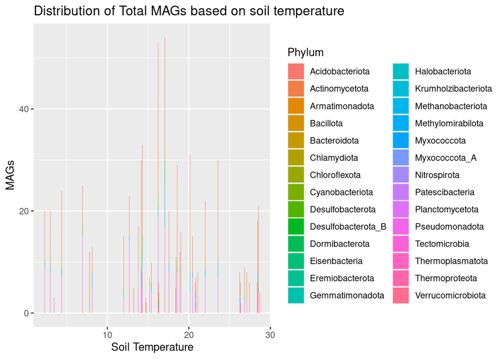

```r
NEON_data %>%
  ggplot(aes(x = soilTemp, fill= Phylum)) +
  geom_bar()+
  labs(title = "Distribution of Total MAGs based on soil temperature", y = "MAGs", x= "Soil Temperature")
```

#### Total MAGs Soil pH

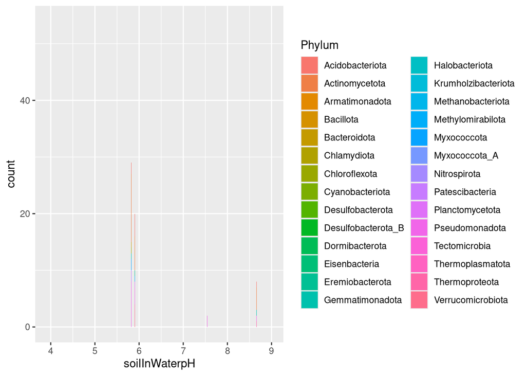

```r
NEON_data %>%
  ggplot(aes(x = soilInWaterpH, fill= Phylum)) +
  geom_bar()
```

```r
  labs(title = "Distribution of Total MAGs based on soil in water pH", y = "MAGs", x= "Soil pH")
```

```
## $y
## [1] "MAGs"
##
## $x
## [1] "Soil pH"
##
## $title
## [1] "Distribution of Total MAGs based on soil in water pH"
##
## attr(,"class")
## [1] "labels"
```

### Ecosystems - Verrucomicrobiota vs. all MAGs

#### Verrucomicrobiota Ecosystem Distribution

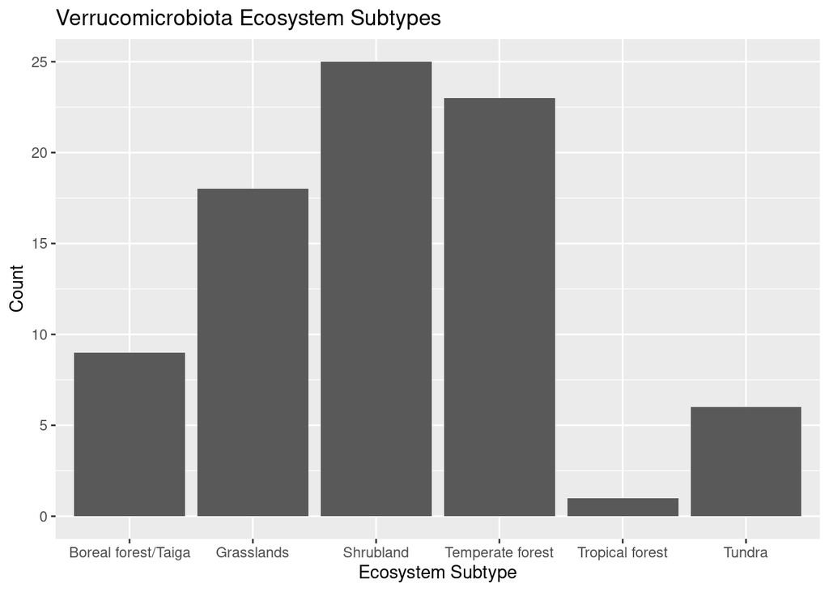

```r
NEON_data_Verruco %>%
  ggplot(aes(x= `Ecosystem Subtype`))+
  geom_bar()+
  labs(title = "Verrucomicrobiota Ecosystem Subtypes", y="Count")
```

#### Verrucomicrobiota Ecosystem Distribution by Order

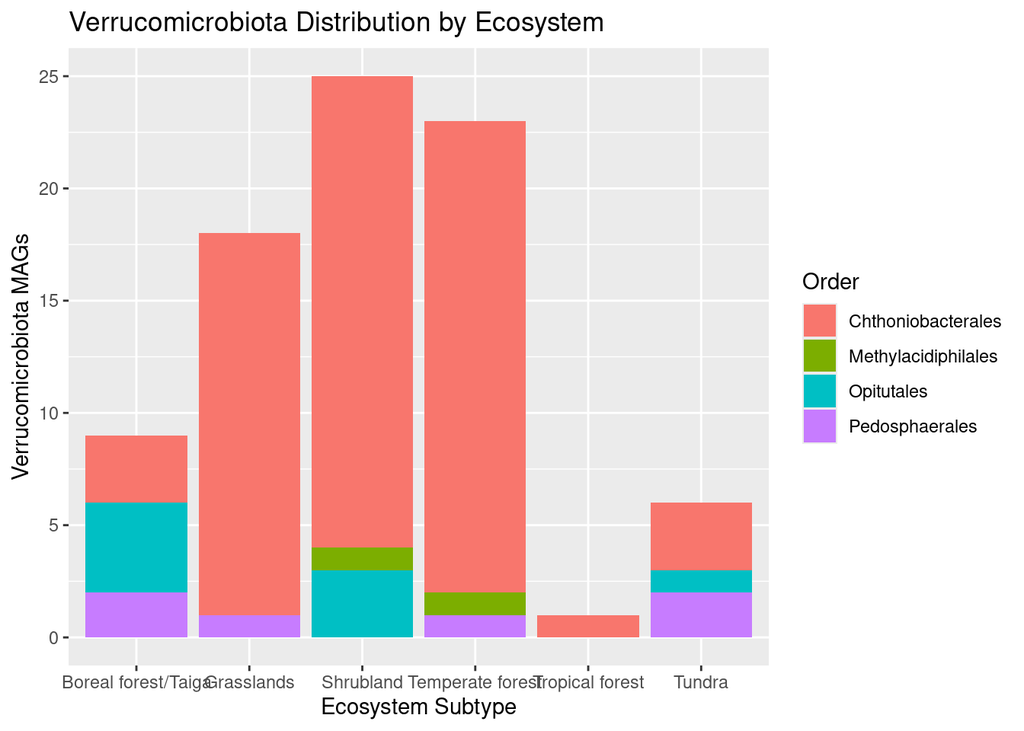

```r
NEON_data_Verruco %>%
  ggplot(aes(x=`Ecosystem Subtype`, fill=Order))+
  geom_bar()+
  labs(title = "Verrucomicrobiota Distribution by Ecosystem", y="Verrucomicrobiota MAGs")
```

### Verrucomicrobiota Ecosystem Subtypes by Site

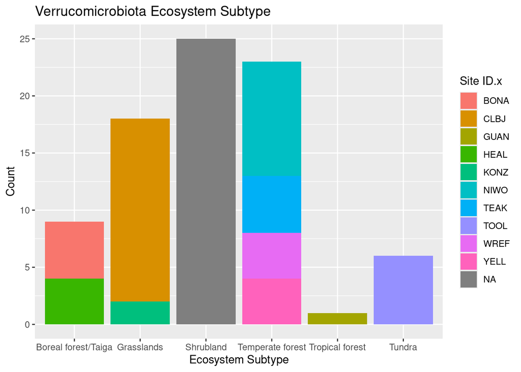

```r
NEON_data_Verruco %>%
  ggplot(aes(x= `Ecosystem Subtype`, fill = `Site ID.x`))+
  geom_bar()+
  labs(title = "Verrucomicrobiota Ecosystem Subtype", y="Count")
```

#### Total MAGs Ecosystem Distribution

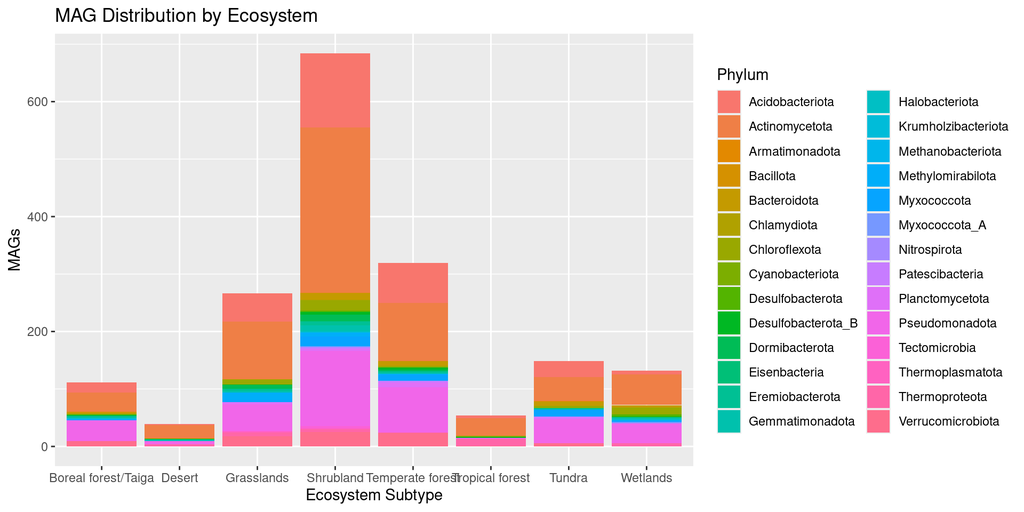

```r
NEON_data %>%
  ggplot(aes(x=`Ecosystem Subtype`, fill= Phylum))+
  geom_bar()+
  labs(title = "MAG Distribution by Ecosystem", y="MAGs")
```

#### Verrucomicrobiota and Ecosystem Subtype Phylogeny

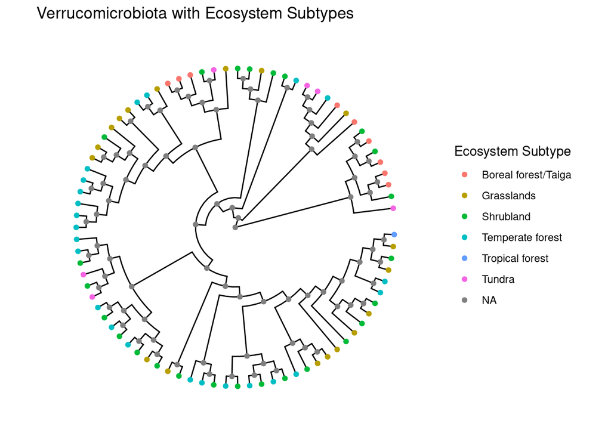

```r
ggtree(tree_Verruco, layout="circular")  %<+%
  NEON_data +
  geom_point2(mapping=aes(color=`Ecosystem Subtype`))+
  ggtitle("Verrucomicrobiota with Ecosystem Subtypes")
```

### Other Soil Properties - Verrucomicrobiota

#### Verrucomicrobiota Distribution and Nitrogen Content

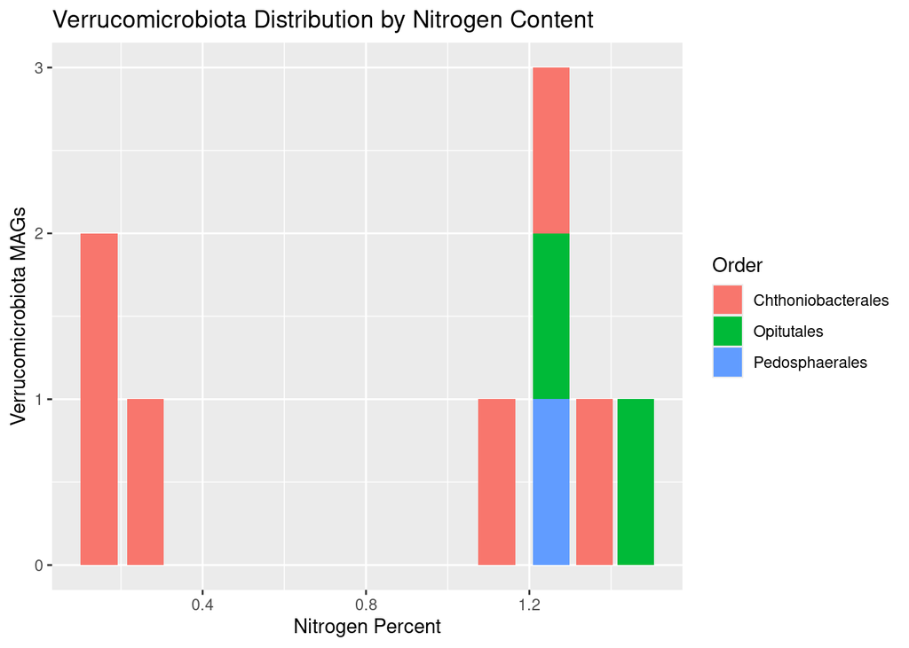

```r
NEON_data_Verruco %>%
  ggplot(aes(x= nitrogenPercent, fill=Order))+
  geom_bar()+
  labs(title = "Verrucomicrobiota Distribution by Nitrogen Content", x="Nitrogen Percent", y="Verrucomicrobiota MAGs")
```

#### Verrucomicrobiota Distribution and Organic Carbon Content

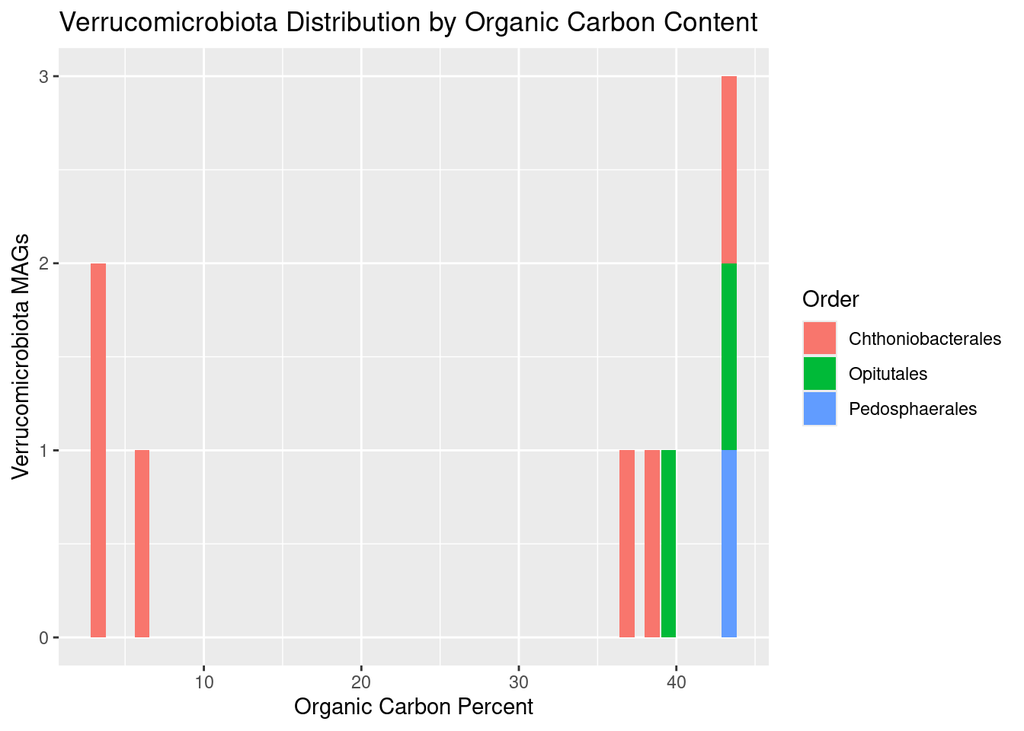

```r
NEON_data_Verruco %>%
  ggplot(aes(x= organicCPercent, fill=Order))+
  geom_bar()+
  labs(title = "Verrucomicrobiota Distribution by Organic Carbon Content", x="Organic Carbon Percent", y="Verrucomicrobiota MAGs")
```

#### Verrucomicrobiota Distribution and Depth of Sample

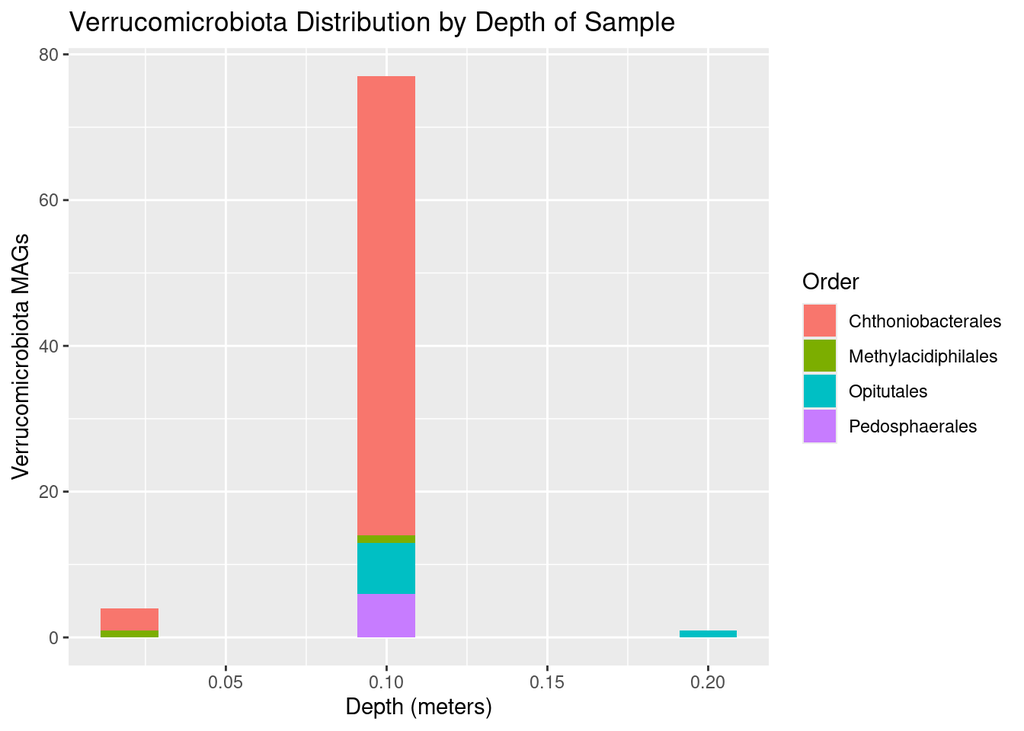

```r
NEON_data_Verruco %>%
  ggplot(aes(x= `Depth In Meters`, fill=Order))+
  geom_bar()+
  labs(title = "Verrucomicrobiota Distribution by Depth of Sample", x="Depth (meters)", y="Verrucomicrobiota MAGs")
```

### Site Data

#### Soil Temperature and Elevation at Niwot Ridge

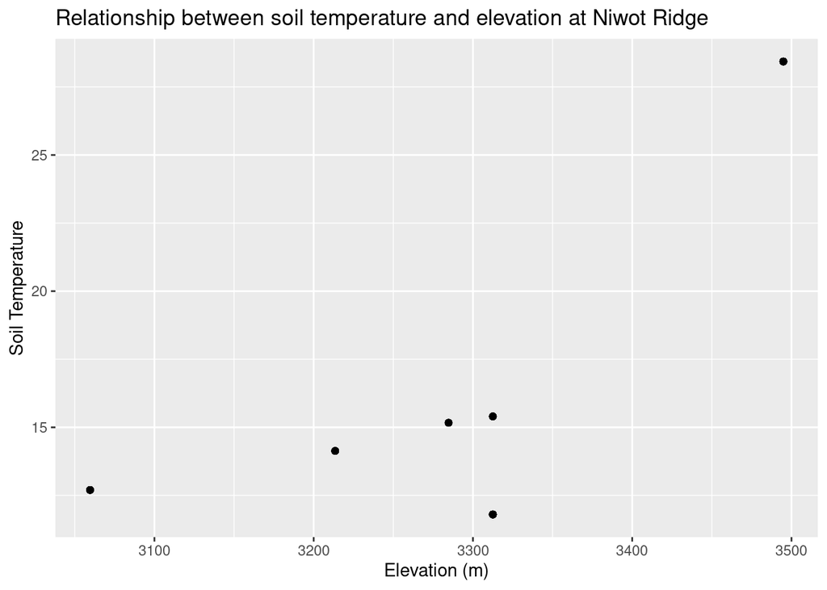

```r
NEON_data_NIWO %>%
  ggplot(aes(x=elevation, y=soilTemp))+
  geom_point()+
  labs(title = "Relationship between soil temperature and elevation at Niwot Ridge", y = "Soil Temperature", x= "Elevation (m)")
```

#### Soil Temperature and Elevation at all sites

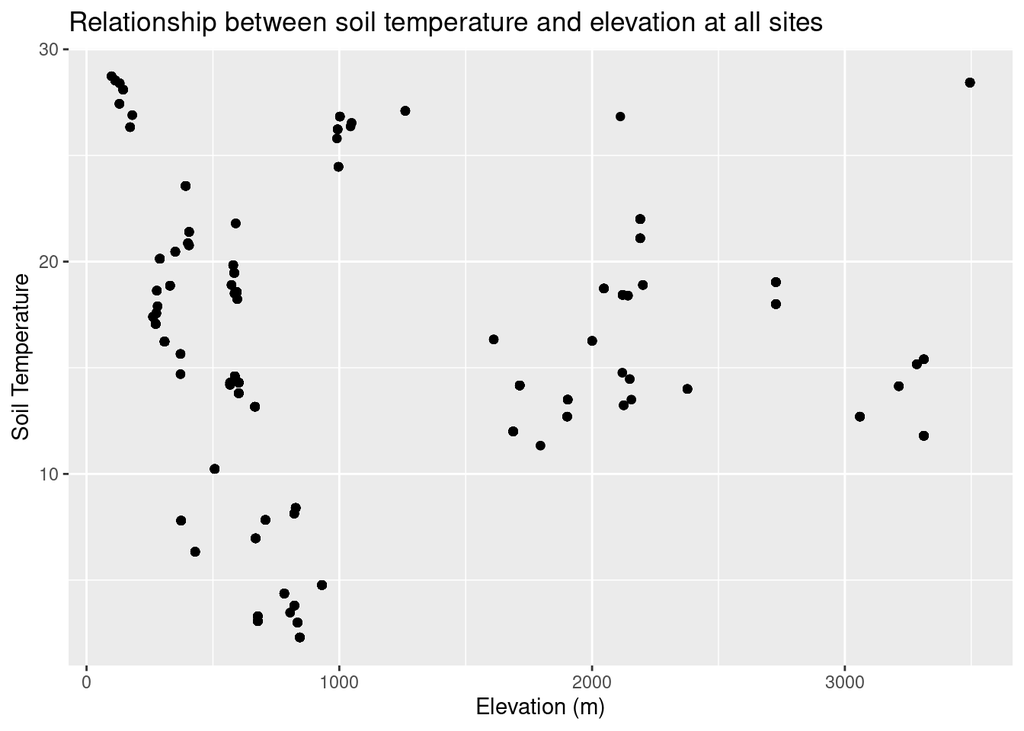

```r
NEON_data %>%
  ggplot(aes(x=elevation, y=soilTemp))+
  geom_point()+
  labs(title = "Relationship between soil temperature and elevation at all sites", y = "Soil Temperature", x= "Elevation (m)")
```

#### Soil pH and Soil Temperature - All Sites

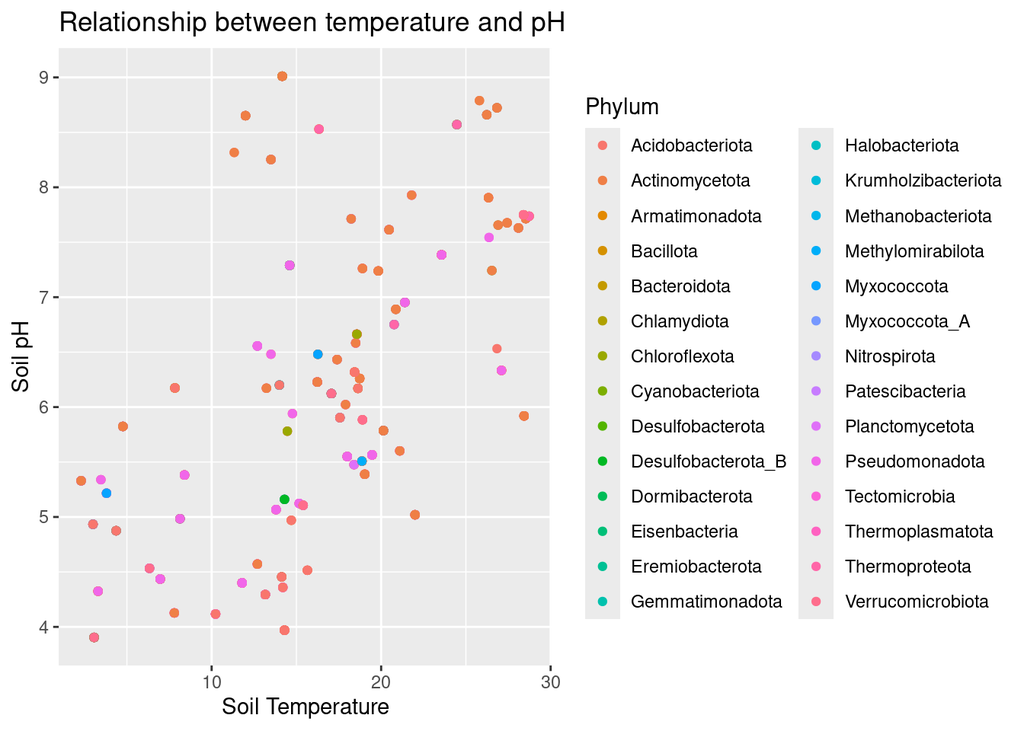

```r
NEON_data %>%
  ggplot(aes(x=soilTemp, y=soilInWaterpH, color = Phylum))+
  geom_point()+
  labs(title = "Relationship between temperature and pH", y = "Soil pH", x= "Soil Temperature")
```

#### Ecosystem Subtype and Soil Temperature

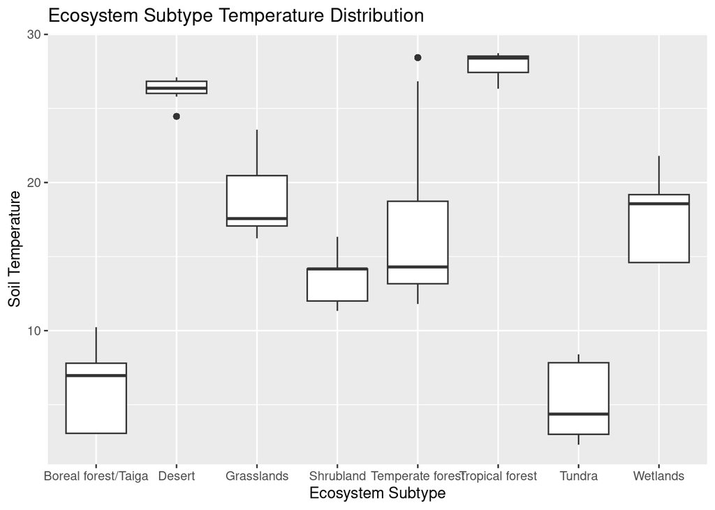

```r
NEON_data %>%
  ggplot(aes(x=`Ecosystem Subtype`, y=soilTemp))+
  geom_boxplot()+
  labs(title = "Ecosystem Subtype Temperature Distribution", y="Soil Temperature")
```

#### Habitat of each Phylum at Niwot Ridge

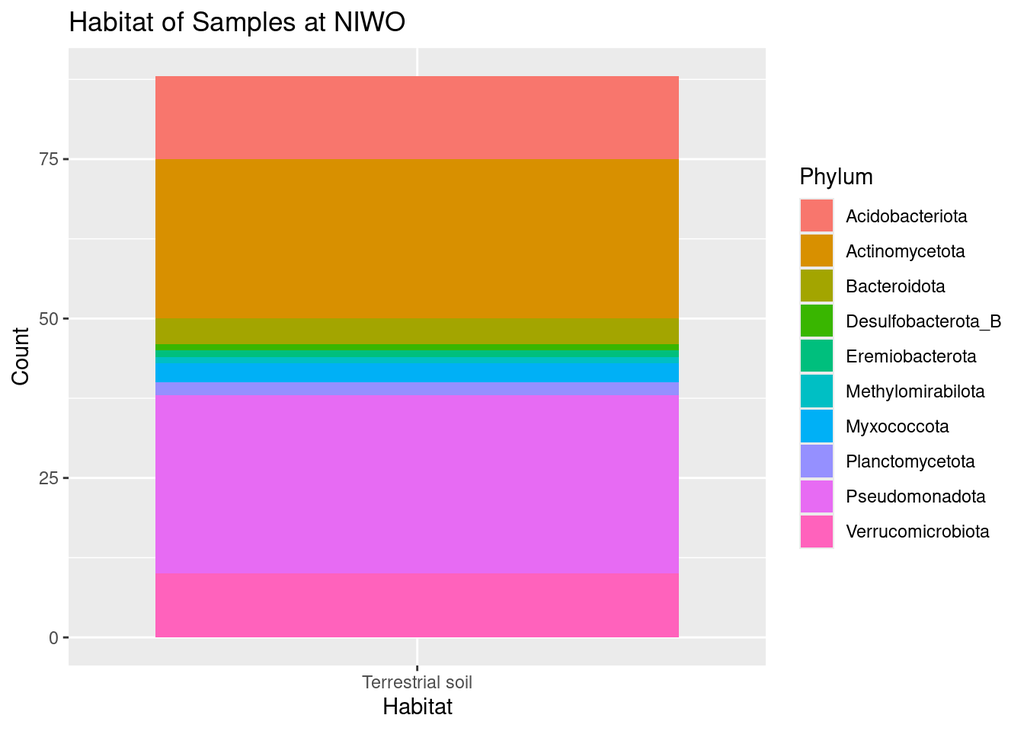

```r
NEON_data_NIWO %>%
  ggplot(aes(x= `Habitat`, fill=Phylum))+
  geom_bar()+
  labs(title = "Habitat of Samples at NIWO", y="Count")
```

#### Mineral vs Organic Soil at Niwot Ridge

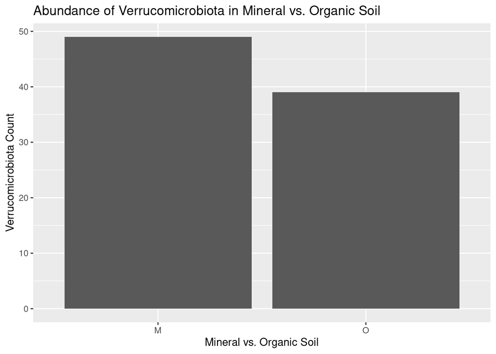

```r
NEON_data_NIWO%>%
  ggplot(aes(x = Layer.x))+
  geom_bar()+
  labs(title = "Abundance of Verrucomicrobiota in Mineral vs. Organic Soil")+
  labs(x = "Mineral vs. Organic Soil", y = "Verrucomicrobiota Count")
```

#### Elevation of Samples Found at Niwot Ridge

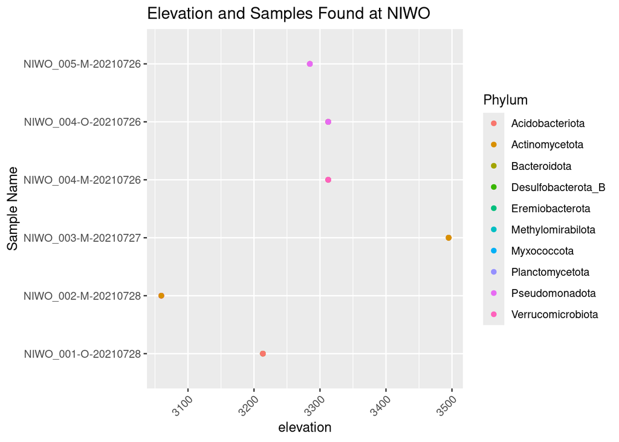

```r
NEON_data_NIWO %>%
ggplot(aes(x = `elevation`, y = `Sample Name`, color = `Phylum`)) +
  geom_point() +
  ggtitle("Elevation and Samples Found at NIWO")+
  theme(axis.text.x = element_text(angle=45, vjust=1, hjust=1))
```

## Genome/Assembly Data

### Sankey Plots

```r
NEON_MAGs_sankey <- read_csv("data/NEON/GOLD_Study_ID_Gs0161344_NEON_2024_4_21.csv") %>%
  select(-c(`GOLD Study ID`, `Bin Methods`, `Created By`, `Date Added`)) %>%
  mutate("Assembly Type" = case_when(`Genome Name` == "NEON combined assembly" ~ `Genome Name`,
                            TRUE ~ "Individual")) %>%
  mutate_at("Assembly Type", str_replace, "NEON combined assembly", "Combined") %>%
  separate(`GTDB-Tk Taxonomy Lineage`, c("Domain", "Phylum", "Class", "Order", "Family", "Genus"), "; ", remove = FALSE) %>%
  mutate_at("Genome Name", str_replace, "Terrestrial soil microbial communities from ", "") %>%
  separate(`Genome Name`, c("Site","Sample Name"), " - ") %>%
  mutate_at("Sample Name", str_replace, "-comp-1", "") %>%
  separate(`Sample Name`, c("Site ID","subplot.layer.date"), "_", remove = FALSE,) %>%
  separate(`subplot.layer.date`, c("Subplot", "Layer", "Date"), "-")
```

```r
NEON_MAGs_ind <- NEON_MAGs_sankey %>%
  filter(`Assembly Type` == "Individual")

NEON_MAGs_co <- NEON_MAGs_sankey %>%
  filter(`Assembly Type` == "Combined")
```

```r
NEON_MAGs_ind_Verruco <- NEON_MAGs_sankey %>%
  filter(`Assembly Type` == "Individual") %>%
  filter(Phylum == "Verrucomicrobiota")

NEON_MAGs_co_Verruco <- NEON_MAGs_sankey %>%
  filter(`Assembly Type` == "Combined") %>%
  filter(Phylum == "Verrucomicrobiota")
```

#### All Combined

```r
sankey_data2 <- NEON_MAGs_co %>%
  select(`GTDB-Tk Taxonomy Lineage`) %>%
  replace_na(list(`GTDB-Tk Taxonomy Lineage` = 'Archaea')) %>%
  separate(`GTDB-Tk Taxonomy Lineage`, c("Domain", "Phylum", "Class", "Order", "Family", "Genus", "Species"), ";")


sankey_data2[] <- t(apply(sankey_data2, 1, zoo::na.locf))



sankey_data2 <- sankey_data2 %>%
  unite(col = "classification", c(Domain, Phylum, Class, Order, Family, Genus, Species), sep=';') %>%
  mutate_at("classification", str_replace, ";", "|") %>%
  mutate_at("classification", str_replace, ";", "|") %>%
  mutate_at("classification", str_replace, ";", "|") %>%
  mutate_at("classification", str_replace, ";", "|") %>%
  mutate_at("classification", str_replace, ";", "|") %>%
  mutate_at("classification", str_replace, ";", "|") %>%
  mutate_at("classification", str_replace, ";", "|")


sankey_data_s <- sankey_data2
sankey_data_g <- sankey_data2
sankey_data_f <- sankey_data2
sankey_data_o <- sankey_data2
sankey_data_c <- sankey_data2
sankey_data_p <- sankey_data2
sankey_data_d <- sankey_data2

sankey_data_g$classification <- sub("\\|s__.*", "", sankey_data_g$classification)
sankey_data_f$classification <- sub("\\|g__.*", "", sankey_data_f$classification)
sankey_data_o$classification <- sub("\\|f__.*", "", sankey_data_o$classification)
sankey_data_c$classification <- sub("\\|o__.*", "", sankey_data_c$classification)
sankey_data_p$classification <- sub("\\|c__.*", "", sankey_data_p$classification)
sankey_data_d$classification <- sub("\\|p__.*", "", sankey_data_d$classification)

sankey_data_allTaxa <- bind_rows(sankey_data_s, sankey_data_g, sankey_data_f, sankey_data_o, sankey_data_c, sankey_data_p, sankey_data_d) %>%
  mutate(classification = as.factor(classification)) %>%
  count(classification) %>%

  rename(`#SampleID` = `classification`) %>%
  rename(`Metaphlan2_Analysis` = `n`)

write_tsv(sankey_data_allTaxa, "data/NEON/NEON_MAG_co_pavian.txt")
```

```r
knitr::include_url("images/all_combined.html")
```

[interactive chart not shown]

#### All Individual

```r
sankey_data2 <- NEON_MAGs_ind %>%
  select(`GTDB-Tk Taxonomy Lineage`) %>%
  replace_na(list(`GTDB-Tk Taxonomy Lineage` = 'Archaea')) %>%
  separate(`GTDB-Tk Taxonomy Lineage`, c("Domain", "Phylum", "Class", "Order", "Family", "Genus", "Species"), ";")


sankey_data2[] <- t(apply(sankey_data2, 1, zoo::na.locf))



sankey_data2 <- sankey_data2 %>%
  unite(col = "classification", c(Domain, Phylum, Class, Order, Family, Genus, Species), sep=';') %>%
  mutate_at("classification", str_replace, ";", "|") %>%
  mutate_at("classification", str_replace, ";", "|") %>%
  mutate_at("classification", str_replace, ";", "|") %>%
  mutate_at("classification", str_replace, ";", "|") %>%
  mutate_at("classification", str_replace, ";", "|") %>%
  mutate_at("classification", str_replace, ";", "|") %>%
  mutate_at("classification", str_replace, ";", "|")


sankey_data_s <- sankey_data2
sankey_data_g <- sankey_data2
sankey_data_f <- sankey_data2
sankey_data_o <- sankey_data2
sankey_data_c <- sankey_data2
sankey_data_p <- sankey_data2
sankey_data_d <- sankey_data2

sankey_data_g$classification <- sub("\\|s__.*", "", sankey_data_g$classification)
sankey_data_f$classification <- sub("\\|g__.*", "", sankey_data_f$classification)
sankey_data_o$classification <- sub("\\|f__.*", "", sankey_data_o$classification)
sankey_data_c$classification <- sub("\\|o__.*", "", sankey_data_c$classification)
sankey_data_p$classification <- sub("\\|c__.*", "", sankey_data_p$classification)
sankey_data_d$classification <- sub("\\|p__.*", "", sankey_data_d$classification)

sankey_data_allTaxa <- bind_rows(sankey_data_s, sankey_data_g, sankey_data_f, sankey_data_o, sankey_data_c, sankey_data_p, sankey_data_d) %>%
  mutate(classification = as.factor(classification)) %>%
  count(classification) %>%

  rename(`#SampleID` = `classification`) %>%
  rename(`Metaphlan2_Analysis` = `n`)

write_tsv(sankey_data_allTaxa, "data/NEON/MAGs_pavian_ind")
```

```r
knitr::include_url("images/all_individual.html")
```

[interactive chart not shown]

### Verrucomicrobiota Properties

#### Verrucomicrobiota Combined and Individual Assemblies

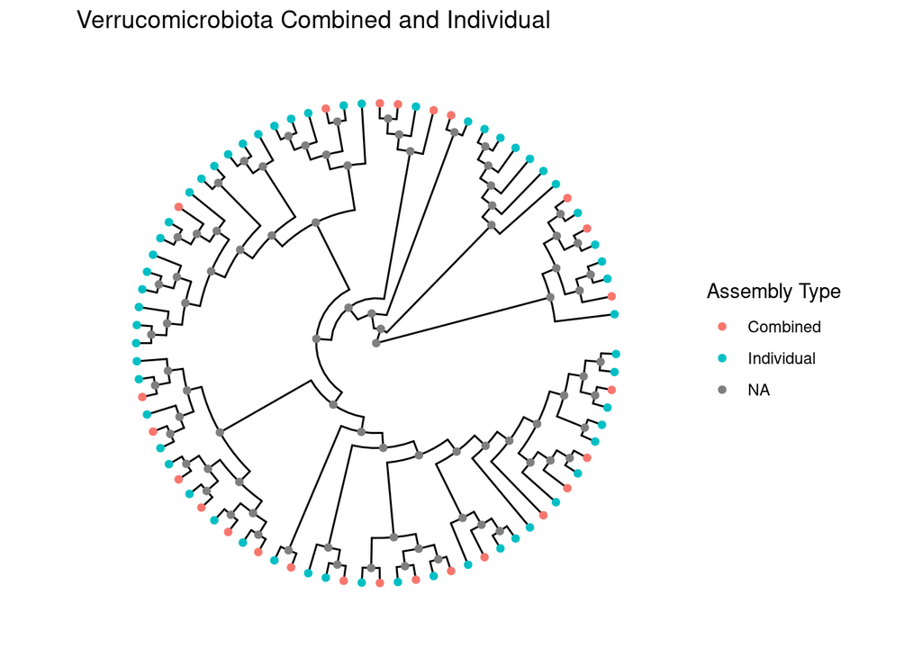

```r
ggtree(tree_Verruco, layout="circular")  %<+%
  NEON_data +
  geom_point2(mapping=aes(color=`Assembly Type`))+
  ggtitle("Verrucomicrobiota Combined and Individual")
```

#### Verrucomicrobiota Genome size and Gene Count

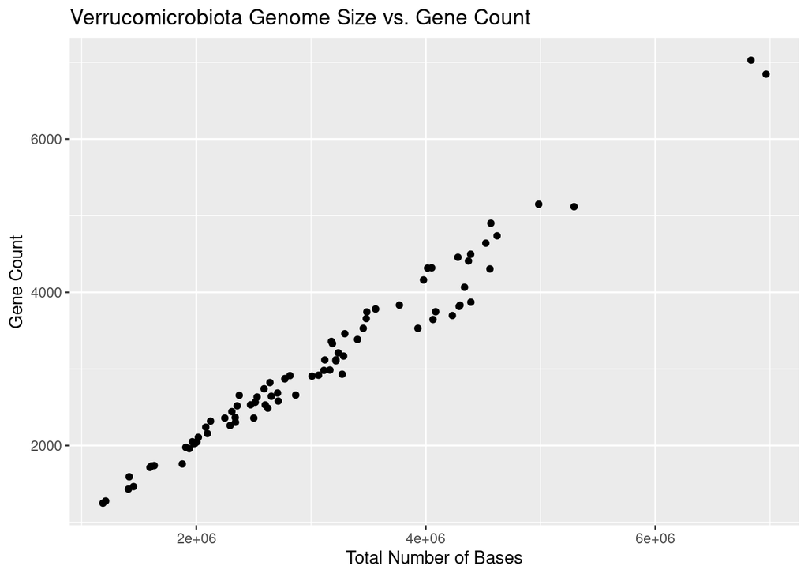

```r
NEON_data_Verruco %>%
  ggplot(aes(x= `Total Number of Bases`, y= `Gene Count` ))+
  geom_point()+
  labs(title = "Verrucomicrobiota Genome Size vs. Gene Count")
```

#### Verrucomicrobiota Order Genome Size Distribution

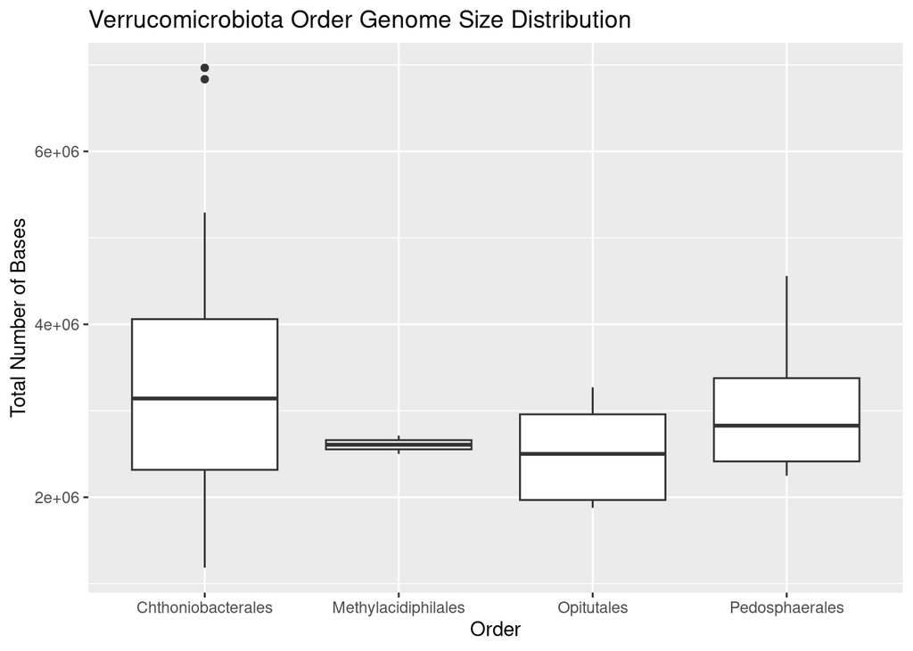

```r
NEON_data_Verruco %>%
  ggplot(aes(x= Order, y= `Total Number of Bases` ))+
  geom_boxplot()+
  labs(title = "Verrucomicrobiota Order Genome Size Distribution")
```

#### Histogram of Verrucomicrobiota Total Number of Bases

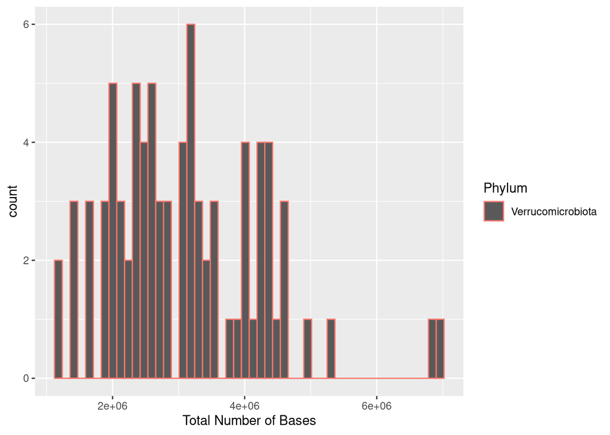

```r
NEON_data_Verruco %>%
ggplot(aes(x = `Total Number of Bases`, color = Phylum)) +
  geom_histogram(bins = 50)
```

#### Verrucomicrobiota Genus Genome Size Distribution

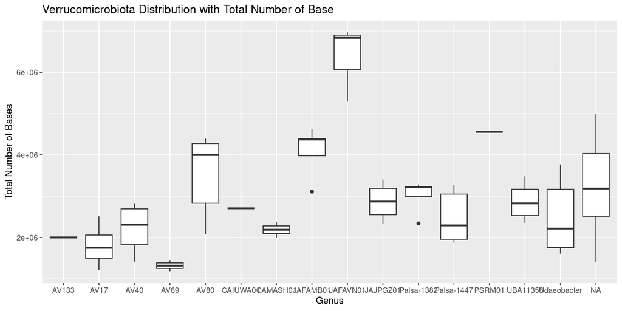

```r
NEON_data_Verruco %>%
  ggplot(aes(x= Genus, y= `Total Number of Bases` ))+
  geom_boxplot()+
  labs(title = "Verrucomicrobiota Distribution with Total Number of Base")
```

#### Verrucomicrobiota Genera Gene Count Distribution

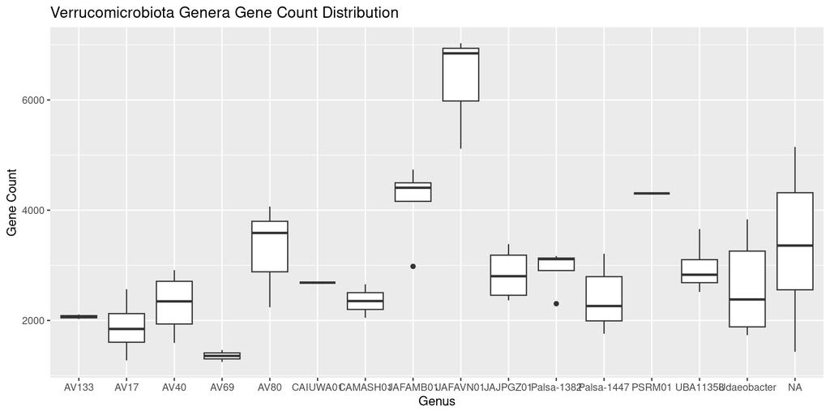

```r
NEON_data_Verruco %>%
  ggplot(aes(x= Genus, y= `Gene Count` ))+
  geom_boxplot()+
  labs(title = "Verrucomicrobiota Genera Gene Count Distribution")
```

#### 16s rRNA Distribution by Genus

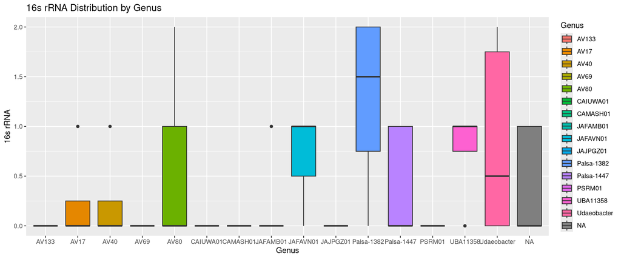

```r
NEON_data_Verruco %>%
  ggplot(aes(x = Genus, y = `16s rRNA`, fill = Genus))+
  geom_boxplot()+
  labs(title = "16s rRNA Distribution by Genus")
```

#### Verrucomicrobiota Genera tRNA Distribution

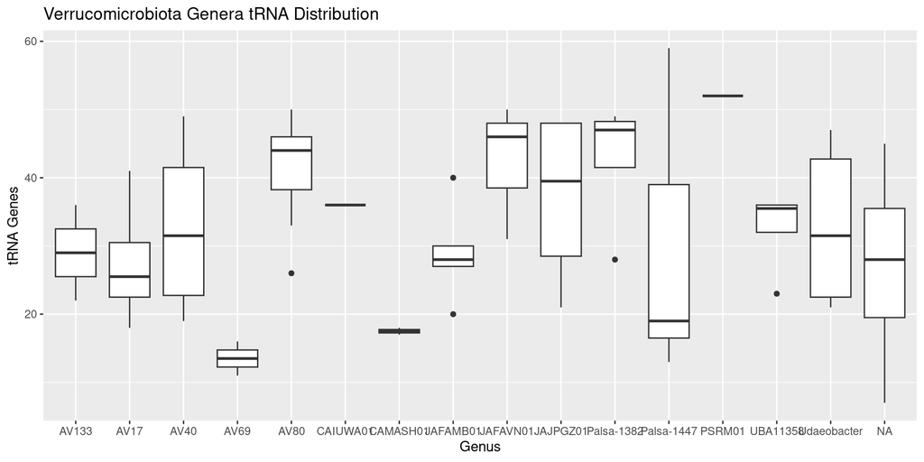

```r
NEON_data_Verruco %>%
  ggplot(aes(x= Genus, y= `tRNA Genes` ))+
  geom_boxplot()+
  labs(title = "Verrucomicrobiota Genera tRNA Distribution")
```

#### Novel Verrucomicrobiota by Order

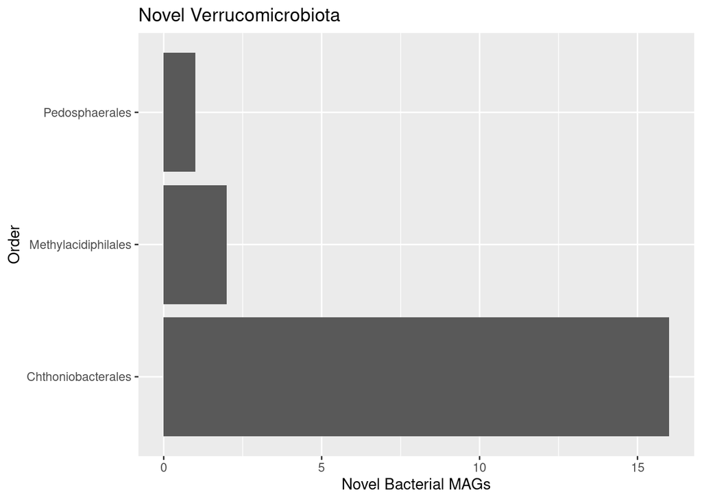

```r
NEON_data_Verruco %>%
  filter(is.na(Genus)) %>%
  ggplot(aes(x= Order))+
  geom_bar()+
  labs(title = "Novel Verrucomicrobiota", y = "Novel Bacterial MAGs", x= "Order") +
  coord_flip()
```

#### Verrucomicrobiota Scaffold Count and Bin Completeness

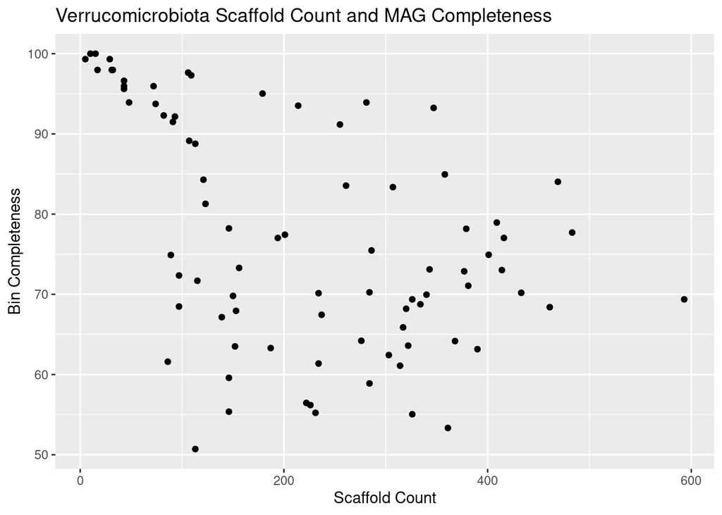

```r
NEON_data_Verruco %>%
  ggplot(aes(x = `Scaffold Count`, y = `Bin Completeness`)) +
  geom_point() +
  labs(title = "Verrucomicrobiota Scaffold Count and MAG Completeness",
       x = "Scaffold Count",
       y = "Bin Completeness")
```

#### Verrucomicrobiota Histogram of Total Number of Bases at Niwot Ridge

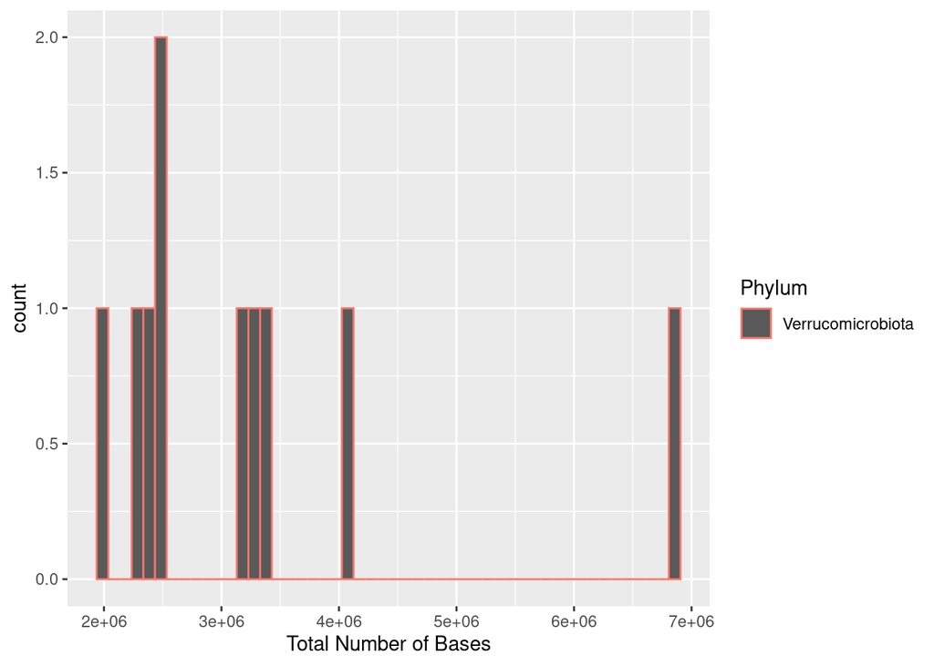

```r
NEON_data_NIWO %>%
  filter(Phylum == "Verrucomicrobiota") %>%
ggplot(aes(x = `Total Number of Bases`, color = Phylum)) +
  geom_histogram(bins = 50)
```

#### Verrucomicrobiota Total Number of Bases and Bin quality

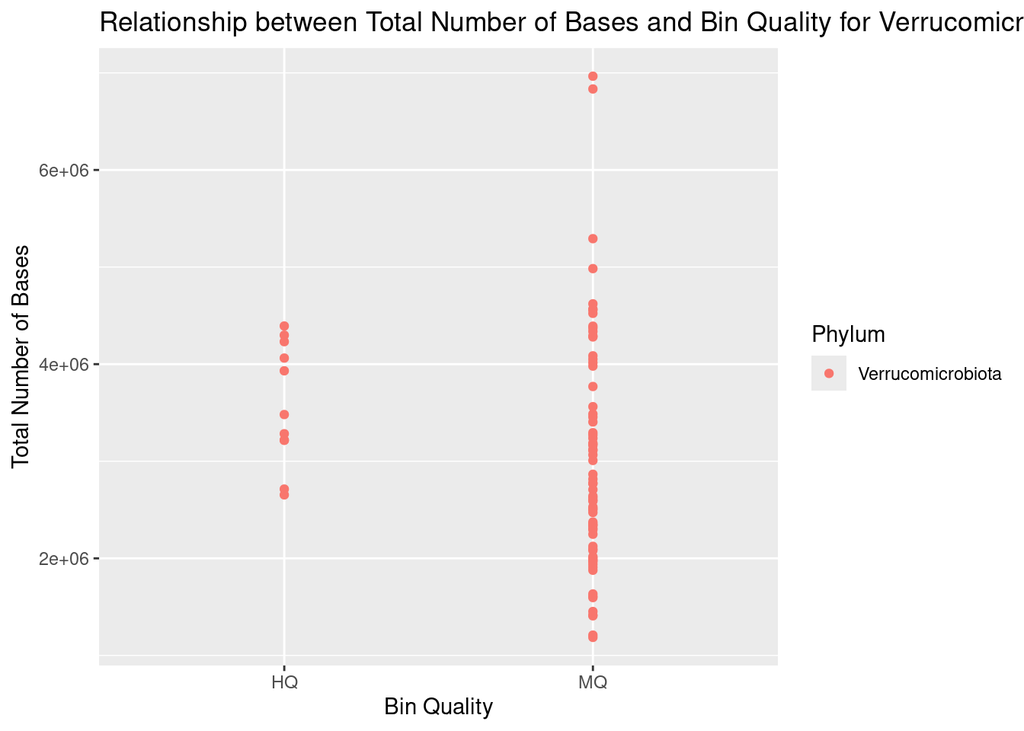

```r
NEON_data_Verruco %>%
  ggplot(aes(x= `Bin Quality`, y= `Total Number of Bases`, color = Phylum))+
  geom_point()+
  labs(title = "Relationship between Total Number of Bases and Bin Quality for Verrucomicrobiota", y = "Total Number of Bases", x= "Bin Quality")
```